# FigureYa261circGene

**Author(s)**: Shuwen Cheng  
**Reviewer(s)**: Ying Ge, Yasi Zhang  
**Date**: 2025-11-20

## 1 Academic Citation

If you use this code in your work or research, we kindly request that you cite our publication:

Xiaofan Lu, et al. (2025). FigureYa: A Standardized Visualization Framework for Enhancing Biomedical Data Interpretation and Research Efficiency. iMetaMed. https://doi.org/10.1002/imm3.70005

To cite package ‘RCircos’ in publications use:

Hongen Zhang, Paul Meltzer and Sean Davis (2013), RCircos: an R package for Circos 2D track plots, BMC Bioinformatics 14:244

## 2 需求描述 Requirement Description

绘制基因位置的环形图。

Drawing a circular diagram of gene locations.

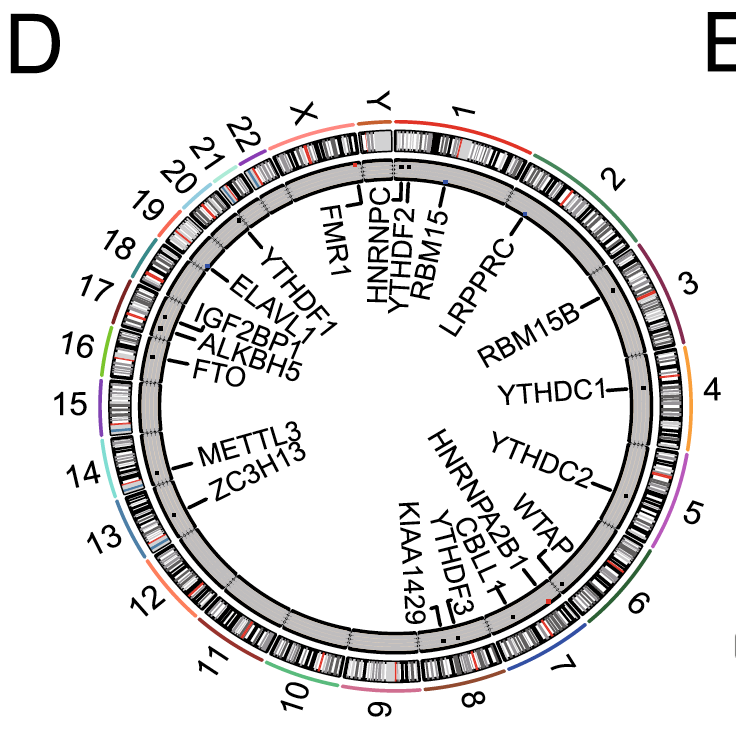

From https://molecular-cancer.biomedcentral.com/articles/10.1186/s12943-020-01170-0

## 3 应用场景 Application Scenario

把几个感兴趣的基因标注在基因组上，可以像这篇例文画成圆的。

如果基因太多，可以画成直的，可参考FigureYa10chromosome，可以同时展示基因表达量/变化倍数、分类等信息。

Mark the genes of interest on the genome, which can be drawn in a circular layout like the example provided.

If there are too many genes, a linear layout can be used (refer to FigureYa10chromosome), which can simultaneously display gene expression levels/fold changes, classifications, and other information.

## 4 环境设置 Environment Setup

```r
source("install_dependencies.R")
```

[output not shown]

```r
library(RCircos)      # 用于绘制环形基因组图，主图形绘制功能
library(magrittr)     # 提供 %>% 管道操作符，简化数据处理流程
library(tidyverse)    # 数据处理与可视化工具集，主要用于数据筛选、变换（如 dplyr、readr）
library(rtracklayer)  # 用于读取和处理基因组注释文件（如 GTF），提取基因位置信息

# 显示英文报错信息
# Show English error messages
Sys.setenv(LANGUAGE = "en")

# 禁止chr转成factor
# Prevent character-to-factor conversion
options(stringsAsFactors = FALSE)
```

## 5 目标基因位置的获取 Obtaining Target Gene Locations

easy_input_gene.txt，根据需要定义一个基因集，后面将把基因名标在画成环状的染色体上。

gencode.v39.annotation.gtf，基因组上所有基因所在位置，从中提取出目标基因的位置。可以从[gencode](https://www.gencodegenes.org)下载https://ftp.ebi.ac.uk/pub/databases/gencode/Gencode_human/release_39/gencode.v39.annotation.gtf.gz。

easy_input_gene.txt: Define a gene set as needed. These gene names will later be labeled on the circular chromosome plot.

gencode.v39.annotation.gtf: Contains the genomic coordinates of all genes. Extract the positions of your target genes from this file. You can download the gencode.v39.annotation.gtf file from [gencode](https://www.gencodegenes.org) at: https://ftp.ebi.ac.uk/pub/databases/gencode/Gencode_human/release_39/gencode.v39.annotation.gtf.gz.

```r
# 根据需要定义一个基因集，可以从文件读入
# Define a gene set as needed and it can be read from a file
genes <- read.table("easy_input_gene.txt", header = T)$SYMBOL

# 也可以直接在这里写入：
# Or can be directly specified here:
#genes <- c("METTL3", "METTL14", "FTO", "ALKBH5","IGF2BP3",
#           "YTHDF1", "YTHDF2", "YTHDF3", "IGF2BP1", "IGF2BP2", )

# 根据基因集提取出目的基因所在位置
# Extract genomic positions of target genes
gene_pos <- import("gencode.v39.annotation.gtf") %>% # 载入gtf文件
  as.data.frame %>%

  # 仅选择基因，去除转录本等等
  # Select only gene entries, filtering out transcripts etc.
  filter(source == "HAVANA", type == "gene") %>%

  # 保留基因位置和名称
  # Keep genomic coordinates and gene names
  dplyr::select(seqnames, start, end, gene_name) %>%

  # 挑选目的基因
  # Filter for target genes
  filter(gene_name %in% genes)
head(gene_pos)

# 原文没说内圈散点图代表什么特征，我们这里随机生成一列数值
# Since the original text didn't specify what the inner scatter points represent, we'll randomly generate a numeric column here
gene_pos$gene_dot <- rnorm(nrow(gene_pos), 0, 2)

# 保存到文件，便于套用格式
# Save to file for easy format reuse
write.csv(gene_pos,"very_easy_input.csv", row.names = F, quote = F)
```

[output not shown]

## 6 开始画图 Start Drawing

very_easy_input.csv，基因、基因在染色体上的位置、基因的某一特征数值。

very_easy_input.csv contains gene names, their chromosomal positions, and a numerical feature value for each gene.

```r
# 加载基因所在的位置和数值
# Load gene positions and associated numerical values
gene_pos <- read.csv("very_easy_input.csv", header = T)

# 加载染色体Ideogram
# Load chromosome ideogram data
(data("UCSC.HG38.Human.CytoBandIdeogram"))
```

```
## [1] "UCSC.HG38.Human.CytoBandIdeogram"
```

```r
# 创建PDF输出文件（5x5英寸）
# Create PDF output file (5x5 inches)
pdf(file="circGene.pdf", height=5, width=5)

# 初始化RCircos核心组件（基于hg38人类细胞遗传图谱）
# Initialize RCircos core components (based on hg38 human cytoband)
RCircos.Set.Core.Components(UCSC.HG38.Human.CytoBandIdeogram,
                            chr.exclude = NULL,
                            tracks.inside = 3,
                            tracks.outside = 0)
RCircos.Set.Plot.Area()

# 绘制染色体
# Draw chromosome ideograms
RCircos.Chromosome.Ideogram.Plot()

# 在第一圈用散点在基因所在的位置标注数值
# 调整配色
# Plot scatter points in Track 1 to show numerical values at gene positions
# Adjust color scheme
param <- RCircos.Get.Plot.Parameters()
param$track.background <- "grey"
RCircos.Reset.Plot.Parameters(param)

# 第一轨道：散点图显示基因数值
# Track 1: Scatter plot for gene values
RCircos.Scatter.Plot(gene_pos,
                     data.col = 5,
                     by.fold = 1,
                     track.num = 1,
                     side = "in")

# 第二轨道：基因连接线（标记基因位置）
# Track 2: Gene connectors (mark gene positions)
RCircos.Gene.Connector.Plot(genomic.data = gene_pos,
                            track.num = 2,
                            side = "in")

# 第三轨道：基因名称标签
# Track 3: Gene name labels
RCircos.Gene.Name.Plot(gene_pos,
                       name.col = 4,
                       track.num = 3,
                       side = "in")

# 关闭图形设备（完成PDF输出）
# Close graphics device (finish PDF output)
dev.off()
```

[figure not shown]

## 7 后期处理 Post-processing

输出到pdf文件为矢量图，可以用Adobe Illustrator等软件打开，编辑图形和文字。例如为避免基因名文字重叠，手动微调文字位置，和修改连线形状。

The plot is exported as a vector graphic in PDF format, which can be opened and edited in software like Adobe Illustrator. For example, you may manually adjust text positions to prevent gene name overlaps and modify connector shapes.